# Predicting exercise manner with random forest method

Adam Sawicki

Sunday, July 27, 2014

I assume the data are downloaded into workspace folder:

https://d396qusza40orc.cloudfront.net/predmachlearn/pml-training.csv https://d396qusza40orc.cloudfront.net/predmachlearn/pml-testing.csv

Load data into R.

```r
raw_pml <- read.table("pml-training.csv", header = T, sep = ",", na.strings = c("#DIV/0!", "", "NA"), dec = ".", stringsAsFactors = T)
```

# Selecting features

Many features have mostly NA values. I certainly don’t want those in the model. As to other features I’ve decided to use only those which hold data from move-measurement devices. This way i can get a classifier independent of user and time.

I have manually selected those features from spreadsheet.

```r
predictors=c("roll_belt","pitch_belt","yaw_belt","total_accel_belt","gyros_belt_x","gyros_belt_y","gyros_belt_z","accel_belt_x","accel_belt_y","accel_belt_z","magnet_belt_x","magnet_belt_y","magnet_belt_z","roll_arm","pitch_arm","yaw_arm","total_accel_arm","gyros_arm_x","gyros_arm_y","gyros_arm_z","accel_arm_x","accel_arm_y","accel_arm_z","magnet_arm_x","magnet_arm_y","magnet_arm_z","roll_dumbbell","pitch_dumbbell","yaw_dumbbell","total_accel_dumbbell","gyros_dumbbell_x","gyros_dumbbell_y","gyros_dumbbell_z","accel_dumbbell_x","accel_dumbbell_y","accel_dumbbell_z","magnet_dumbbell_x","magnet_dumbbell_y","magnet_dumbbell_z","roll_forearm","pitch_forearm","yaw_forearm","total_accel_forearm","gyros_forearm_x","gyros_forearm_y","gyros_forearm_z","accel_forearm_x","accel_forearm_y","accel_forearm_z","magnet_forearm_x","magnet_forearm_y","magnet_forearm_z")
```

# Creating datasets

Create data frame which holds all the data I want.

```r
pml=raw_pml[,c("classe", predictors)]
```

Divide the data into a training and testing set.

```r
require(caret)
inTrain=createDataPartition(pml$classe,p = 0.5, list = F)
training=pml[inTrain,]
testing=pml[-inTrain,]
```

# Creating first model

I’ve decided to use random forest method, only because it’s quite fast, accurate and easy to implement.

For the first model I’m going to use default parameters.

```r
require(randomForest)
fit_rf=randomForest(classe ~ ., data=training)
```

```r
print(fit_rf)
```

```
##
## Call:
##  randomForest(formula = classe ~ ., data = training)
##                Type of random forest: classification
##                      Number of trees: 500
## No. of variables tried at each split: 7
##
##         OOB estimate of  error rate: 1%
## Confusion matrix:
##      A    B    C    D    E class.error
## A 2781    6    2    1    0    0.003226
## B   16 1872   11    0    0    0.014218
## C    0   20 1688    3    0    0.013442
## D    0    0   25 1580    3    0.017413
## E    0    0    3    8 1793    0.006098
```

The results are impressive. Extremely low error of 1%.

Now let’s see the plot for this model.

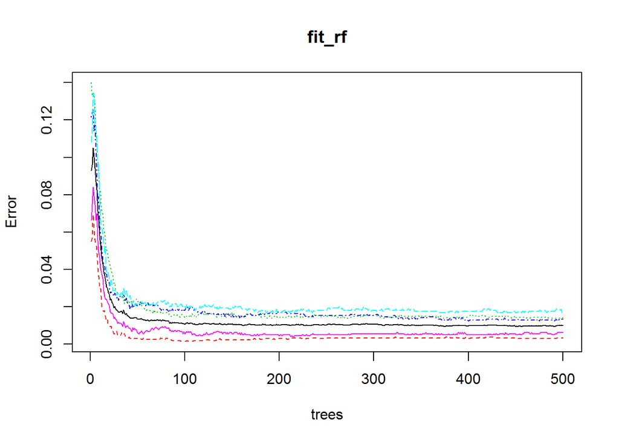

```r
plot(fit_rf)
```

This plot shows how the main OOB error and class errors changed with growth of forest. It looks like errors hit a plateau at around 50 trees in forest. That means I could use only 50 trees in the model and still get very low error.

Now let’s have a look at variable importance.

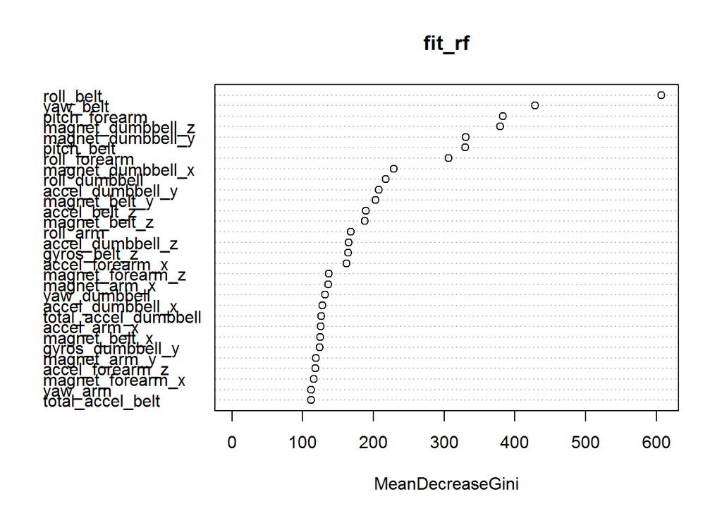

```r
varImpPlot(fit_rf)
```

Few features are of much greater importance than others. I’ll extract those features and build a second model with those most important features only.

```r
important_predictors=rownames(fit_rf$importance[fit_rf$importance>220,0])
```

# Second model

For this model i will set number of trees to 50, and use only most important features as predictors.

```r
fit_rfi=randomForest(classe ~ .,
                    data=training[,c("classe", important_predictors)],
                    ntree = 50)
```

Computing of this model was much faster. Let’s see the results.

```r
print(fit_rfi)
```

```
##
## Call:
##  randomForest(formula = classe ~ ., data = training[, c("classe",      important_predictors)], ntree = 50)
##                Type of random forest: classification
##                      Number of trees: 50
## No. of variables tried at each split: 2
##
##         OOB estimate of  error rate: 2.85%
## Confusion matrix:
##      A    B    C    D    E class.error
## A 2749   18   19    3    1     0.01470
## B   43 1790   45   17    4     0.05740
## C    5   25 1659   21    1     0.03039
## D    0    4   32 1565    7     0.02674
## E    0   22    5    8 1769     0.01940
```

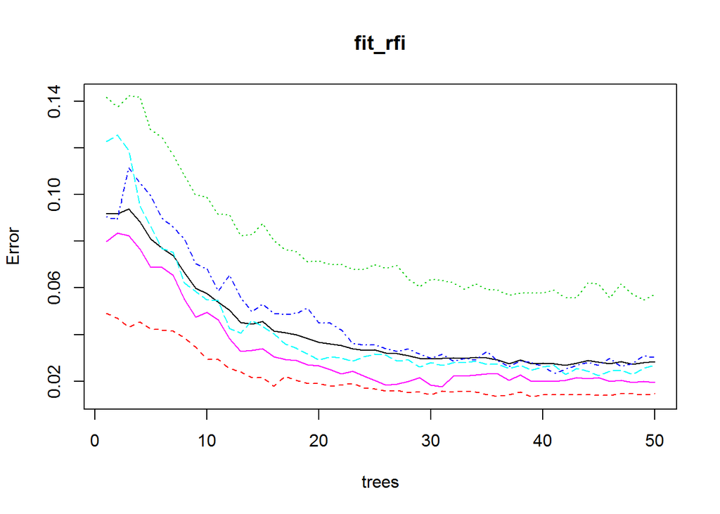

```r
plot(fit_rfi)
```

The error is higher, but still small enough for this project. It’s not fault of ntree=50, because errors hit plateau at around 30 trees on the plot. Higher error is a result of lower number of predictor features. Well, let’s call it a deal. Higher error for lower computing cost.

# Final model with cross validation

In random forests, there is no need for cross-validation to get an estimate of the test set error. Out Of Bag (OOB) error is estimated internally , during the run.

However cross validation is required in the project. So I’ll do it with caret package. I’ll use K-fold method with k=10.

```r
fitControl <- trainControl(method = "cv", number = 10)
```

The rest of parameters will be the same as in previous model.

```r
rfGrid <-  expand.grid(mtry = 2)
train_rf=train(classe~., data=training[,c("classe", important_predictors)],
               method = "rf",
               trControl = fitControl,
               tuneGrid = rfGrid,
               ntree = 50)
```

Now let’s have a look at results of cross validation.

```r
train_rf$resample
```

```
##    Accuracy  Kappa Resample
## 1    0.9755 0.9691   Fold01
## 2    0.9715 0.9639   Fold02
## 3    0.9715 0.9640   Fold03
## 4    0.9735 0.9665   Fold04
## 5    0.9705 0.9627   Fold05
## 6    0.9806 0.9755   Fold06
## 7    0.9776 0.9716   Fold07
## 8    0.9806 0.9755   Fold08
## 9    0.9755 0.9690   Fold09
## 10   0.9786 0.9730   Fold10
```

```r
sd(train_rf$resample[,1])
```

```
## [1] 0.003773
```

```r
mean(train_rf$resample[,1])
```

```
## [1] 0.9755
```

```r
1-mean(train_rf$resample[,1])
```

```
## [1] 0.02446
```

OOB = 1 - Accuracy. So the expected out of sample error for this model is 0.02445851 . As I expected this estimate is very close to the OOB value from previos model.

# Testing the final model

Create predictions for testing set with final model.

```r
predictions_test=predict(object = train_rf, newdata = testing)
```

Check for correctness of those predictions.

```r
correct_test= predictions_test==testing$classe
```

Compute accuracy.

```r
accuracy_test=mean(correct_test)
print(accuracy_test)
```

```
## [1] 0.9879
```

Print confusion matrix for testing set.

```r
table(predictions_test,testing$classe)
```

```
##
## predictions_test    A    B    C    D    E
##                A 2763   17    0    0    1
##                B    9 1851   11    5   13
##                C   14   20 1694    3    4
##                D    3    9    6 1599    1
##                E    1    1    0    1 1784
```

Not surprisingly the accuracy estimate from final model is almost equal to accuracy on test set.

```r
mean(train_rf$resample[,1]) - accuracy_test
```

```
## [1] -0.01233
```

The end.